# Preparing data from SPSS

Guido Biele

22 februar 2019

In this sessin we will open SPSS data files in R and do some simple manipulations. The data we are using are *synthetic!!* Moba data. That is, data have the same marginal distributions and the same covariance as real Moba data, except that they are simulated. Such data can be generated with the [Genord](https://cran.rstudio.com/web/packages/GenOrd/index.html) package, which is specifically desined to simulate ordinal data.

## Loading data from SPSS

SPSS data, i.e. .sav files, can be loaded with the [foreign](https://cran.rstudio.com/web/packages/foreign/index.html) or [haven](https://cran.rstudio.com/web/packages/haven/index.html) packages. Here we use the haven package. If you are using a package for the first time, it can make sense to have a quick look at the documentation, in order to learn what functions exists and what these functions do. The documentations are, like the packages on CRAN, which stands for “Comprehensive R Archive Network”. Here is the haven documentation: https://cran.rstudio.com/web/packages/haven/haven.pdf. more information about the package is [here](https://cran.rstudio.com/web/packages/haven/index.html)

Ok lets get started. We load the package.

```r
library(haven)
```

If we look at the [haven documentation](https://cran.rstudio.com/web/packages/haven/haven.pdf) to see what functions are available. The functions `read_spss`looks promising. So we use this to load the data files. We also immediately make them to data.frame.

```r
MFR = data.frame(read_spss("data/sMFR.sav"))
Q5aar = data.frame(read_spss("data/Q5aar.sav"))
Q8aar = data.frame(read_spss("data/Q8aar.sav"))
```

Next we look at which variables we got:

```r
names(MFR)
```

```
## [1] "KJONN"             "MORS_ALDER_KAT_K8" "PARITET_5"
## [4] "FMND"              "PREG_ID_439"       "BARN_NR"
```

```r
names(Q5aar)
```

```
##  [1] "LL526"       "LL527"       "LL528"       "LL529"       "LL530"
##  [6] "LL531"       "LL532"       "LL533"       "LL534"       "PREG_ID_439"
## [11] "BARN_NR"
```

```r
names(Q8aar)
```

```
##  [1] "NN68"        "NN69"        "NN70"        "NN71"        "NN72"
##  [6] "NN73"        "NN74"        "NN75"        "NN76"        "NN77"
## [11] "NN78"        "NN79"        "NN80"        "NN211"       "NN212"
## [16] "NN213"       "NN214"       "NN215"       "NN216"       "NN217"
## [21] "NN218"       "NN219"       "NN220"       "NN221"       "NN222"
## [26] "NN223"       "NN224"       "NN225"       "NN226"       "NN227"
## [31] "NN228"       "NN229"       "NN230"       "NN231"       "NN232"
## [36] "NN233"       "NN374"       "NN111"       "NN112"       "NN113"
## [41] "NN114"       "NN115"       "NN116"       "NN117"       "NN118"
## [46] "NN119"       "NN120"       "NN121"       "NN122"       "NN123"
## [51] "NN124"       "NN125"       "NN126"       "NN127"       "NN128"
## [56] "NN129"       "NN130"       "NN131"       "NN132"       "NN133"
## [61] "NN134"       "NN135"       "NN136"       "NN137"       "NN138"
## [66] "NN139"       "NN140"       "NN141"       "NN142"       "NN143"
## [71] "NN144"       "PREG_ID_439" "BARN_NR"
```

This is not very clear. However, we know that these data are in the “labelled” format. That is, for each variable we have what SPSS calls variable and value labels. In R, those are the `label`and `labels` attributes:

```r
for (k in 1:ncol(Q5aar))
  print(attr(Q5aar[,k],"label"))
```

```
## [1] " W_53_1:SKJEMA_5AARB; Du lar barnet ditt forstå når han/hun gjør en god innsats; 53. Hvor ofte hender dette hjemme hos dere?"
## [1] " W_53_2:SKJEMA_5AARB; Du truer med å straffe barnet ditt, og så gjennomfører du ikke straffen når det kommer til stykket; 53. Hvor ofte hender dette hjemme hos dere?"
## [1] " W_53_3:SKJEMA_5AARB; Du har en hyggelig samtale med barnet ditt; 53. Hvor ofte hender dette hjemme hos dere?"
## [1] " W_53_4:SKJEMA_5AARB; Barnet snakker seg vekk fra å bli straffet etter å ha gjort noe galt; 53. Hvor ofte hender dette hjemme hos dere?"
## [1] " W_53_5:SKJEMA_5AARB; Du spør barnet ditt om hvordan hans/hennes dag i barnehagen har vært; 53. Hvor ofte hender dette hjemme hos dere?"
## [1] " W_53_6:SKJEMA_5AARB; Du sier noe pent til barnet ditt når han/hun har gjort noe bra; 53. Hvor ofte hender dette hjemme hos dere?"
## [1] " W_53_7:SKJEMA_5AARB; Du roser barnet ditt om han/hun oppfører seg pent; 53. Hvor ofte hender dette hjemme hos dere?"
## [1] " W_53_8:SKJEMA_5AARB; Du snakker med barnet om hans/hennes venner; 53. Hvor ofte hender dette hjemme hos dere?"
## [1] " W_53_9:SKJEMA_5AARB; Du lar barnet ditt slippe tidlig fra en straff (for eksempel oppheve restriksjoner/forbud tidligere enn du f�rst sa); 53. Hvor ofte hender dette hjemme hos dere?"
## [1] "PREG_ID_439"
## [1] "BARN_NR"
```

OK, this are our questions about parenting scale. Now we can look up the `labels` attribute to see how the variable is coded:

```r
attr(Q5aar[,1],"labels")
```

```
## Mer enn ett kryss             Aldri      Nesten aldri       Noen ganger
##                 0                 1                 2                 3
##              Ofte            Alltid
##                 4                 5
```

Here we see one “issue” with MoBa data. Multiple responses are coded with 0, instead of “NA”. So we need to set all zero values to missing, `NA` in the R language. To do this, we use *logical indexing*.

Before w correct this, lets look at a short example to exlain how a for-loop works. The for loop has the following structure:

```r
for (k in all_ks) {
  do_something_with_k
}
```

Typically `all_ks` is a vector with number or strings. A simple example would be

```r
all_ks = c(1,2,3,4,5)
# or equivalently
all_ks = 1:5

for (k in all_ks) {
  y = k * 3
  print(y)
}
```

As you can see from this example, we can define new variables in a loop (here `y`) and use it for further computations. It is important to remember, that if you had defined a variable `y` before, this would be overwriten by the action in the loop! [here](https://www.datacamp.com/community/tutorials/tutorial-on-loops-in-r?) you can ead more about loops in R.

Using such a for loop, we can now set all 0-values to missing, that is to `NA`.

```r
for (k in 1:9) {
  is_zero = which(Q5aar[,k] == 0)
  Q5aar[is_zero,k] = NA
}
```

We can also get a bit more fancy than that by exploiting that the values labels are a named vector:

```r
for (k in 1:ncol(Q8aar)) {
  value_lables = attr(Q8aar[,k], "labels")
  is_zero = which(Q8aar[,k] == value_lables["Mer enn ett kryss"])
  Q8aar[is_zero,k] = NA
}
```

In this section, we used the `==` command, which makes a logical query. In particular, the command `Q8aar[,k] == value_lables["Mer enn ett kryss"]` asks “Which entries in column `k` of the data frame `Q5aar` have a value equal to the value with thenames”Mer enn ett kryss“”? and returns a new vector that has the values `TRUE` or `FALSE`. The command `which` just gives us the positions of such a vector where the value is `TRUE`. The following example shows this:

```r
test = c(1,2,3,4,5,6,7,8,9,10)
is_larger_5 = test > 5
index_is_larger_5 = which(is_larger_5)

print(is_larger_5)
```

```
##  [1] FALSE FALSE FALSE FALSE FALSE  TRUE  TRUE  TRUE  TRUE  TRUE
```

```r
print(index_is_larger_5)
```

```
## [1]  6  7  8  9 10
```

Next, we rename variable so tha they are more intuitive:

```r
item_names = paste0("PSi.",1:9)
names(Q5aar)[1:9] = item_names
head(Q5aar)
```

```
##   PSi.1 PSi.2 PSi.3 PSi.4 PSi.5 PSi.6 PSi.7 PSi.8 PSi.9 PREG_ID_439
## 1     4     2     4     2     5     4     4     4     2           2
## 2     4     3     4     2     4     4     4     4     2           3
## 3     5     2     4     1     5     5     4     4     2           4
## 4     4     2     4     2     5     5     4     4     3           5
## 5     5     3     4     2    NA     5     5     5     2           6
## 6     4     1     4     1     5     5     5     5     2           7
##   BARN_NR
## 1       1
## 2       1
## 3       1
## 4       1
## 5       1
## 6       1
```

For the 8 year questioannaire I looked uo the MoBa documentaion to see which variables belong to which questionnnaire:

```r
scales = list(SMFQ = 68:80,
             CCC2 = 211:226,
             SPRK20 = c(227:233, 374),
             CD = 111:118,
             ADHD = 119:136,
             OD = 137:144)

for (s in names(scales)) {
  original_names = paste0("NN",scales[[s]])
  original_names_idx = which(names(Q8aar) %in% original_names)
  new_names = paste0(s,"i.",1:length(scales[[s]]))
  names(Q8aar)[original_names_idx] = new_names
}

head(Q8aar)
```

```
##   SMFQi.1 SMFQi.2 SMFQi.3 SMFQi.4 SMFQi.5 SMFQi.6 SMFQi.7 SMFQi.8 SMFQi.9
## 1       2       1       1       1       1       1       1       1       1
## 2       1       1       1       1       1       1       1       1       1
## 3       2       1       3       1       1       1       1       2       1
## 4       2       1       1       1       1       1       1       1       1
## 5       2       1       1       1       1       2       1       1       1
## 6       2       1       1       1       1       1       1       1       1
##   SMFQi.10 SMFQi.11 SMFQi.12 SMFQi.13 CCC2i.1 CCC2i.2 CCC2i.3 CCC2i.4
## 1        1        1        1        1       1       1       1       1
## 2        1        1        1        1       1       1       1       1
## 3        1        1        1        2       1       2       2       2
## 4        1        1       NA        1       2       1       1       1
## 5        1        1        1        1       1       1       1       1
## 6        1        1        1        1       1       1       1       1
##   CCC2i.5 CCC2i.6 CCC2i.7 CCC2i.8 CCC2i.9 CCC2i.10 CCC2i.11 CCC2i.12
```

[output cut: 48 more lines]

## Merging data

In R we can use a simple `merge` command to combine data.frames.

```r
identifier_variables = c("PREG_ID_439","BARN_NR")
my_data = merge(MFR,Q5aar, by = identifier_variables)
my_data = merge(my_data,Q8aar, by = identifier_variables)
```

One last thing we can do before looking at the data is to convert from the “labeled” type to an “ordered factor”, so that R knows that questionaire responses are on the ordinal scale.

```r
items = grep("i.[0-9]",names(my_data), value = T)
for (v in items) {
  item_levels = attr(my_data[,v],"labels")
  if (names(item_levels)[1] == "Mer enn ett kryss")
    attr(my_data[,v],"labels") = item_levels[-1]
  my_data[,v] = as_factor(my_data[,v],ordered = T)
}
```

## Exploring data with tables and plots

Before one does anything else, one should first have a look at missingness. A simple way to get a first view is to plot a histogram of the the number of missing data per variable and per person.

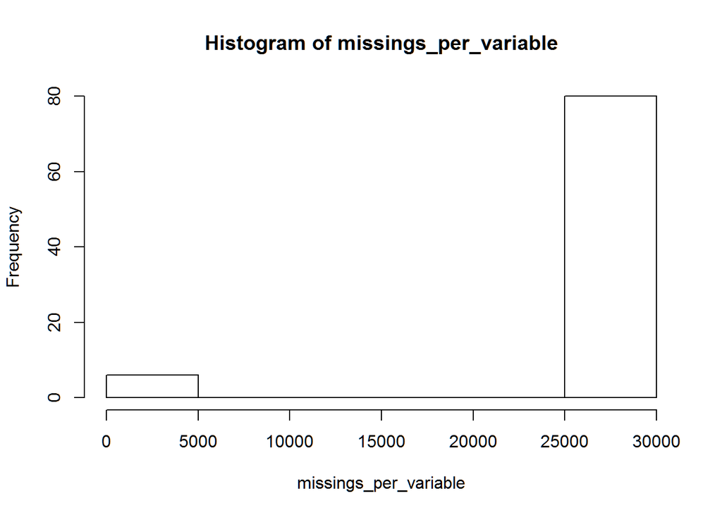

```r
missings = is.na(my_data)
missings_per_variable = colSums(missings)
hist(missings_per_variable)
```

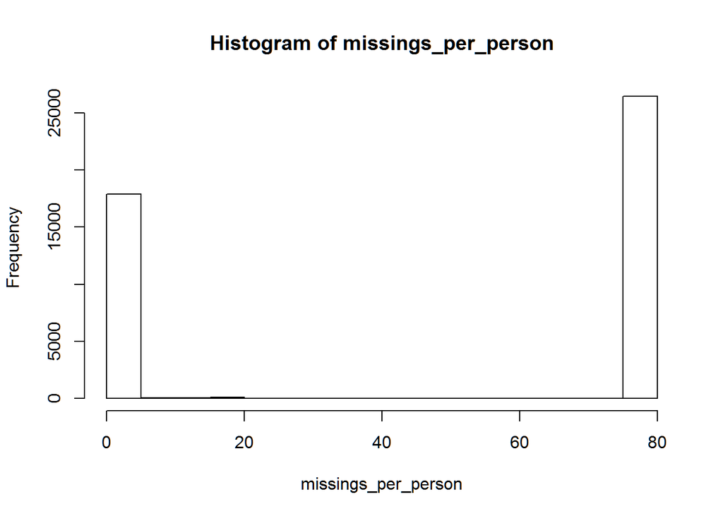

```r
missings_per_person = rowSums(missings)
hist(missings_per_person)
```

Here, `missings_per_person`is more interesting, because is shows us that for ca. 30000 participants we have more than 60 missing variables. Lets replot this as percent missing:

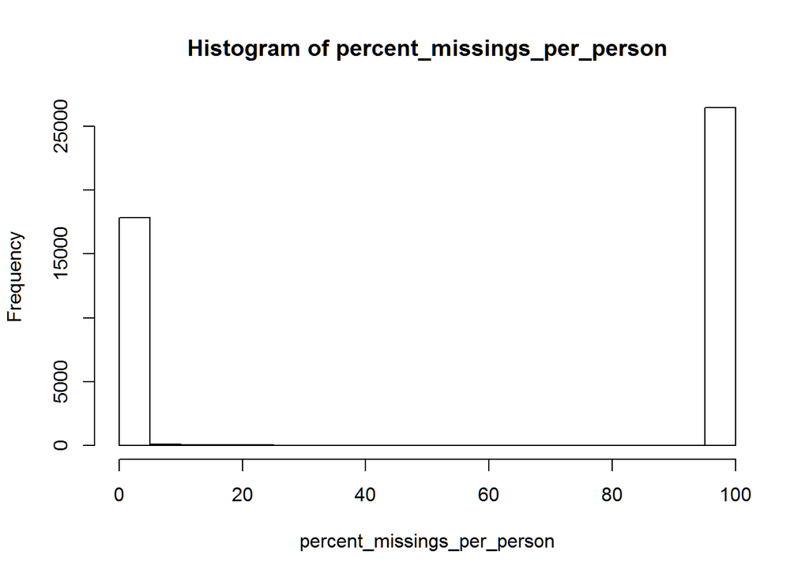

```r
percent_missings_per_person = missings_per_person/(ncol(my_data)-2)*100
hist(percent_missings_per_person)
```

OK, more than 80% missing for around 30000 participants. This is loss to follow up in MoBa. That is, this are individuals who agreed to be part of MoBa and for which we therefore have MFR data, but for which we do not have data from teh 5 or 8 years qestionnnaire. We use logical indexing to remove these people from the data.frame `my_data`. (Note that for a proper analysis we would want to check if loss to follow up is random. It probably isn’t, but dealing with this type of selection bias is a topic on its own.)

```r
my_data = my_data[percent_missings_per_person < 80,]
nrow(my_data)
```

```
## [1] 18185
```

Now we can again look at missings per variable.

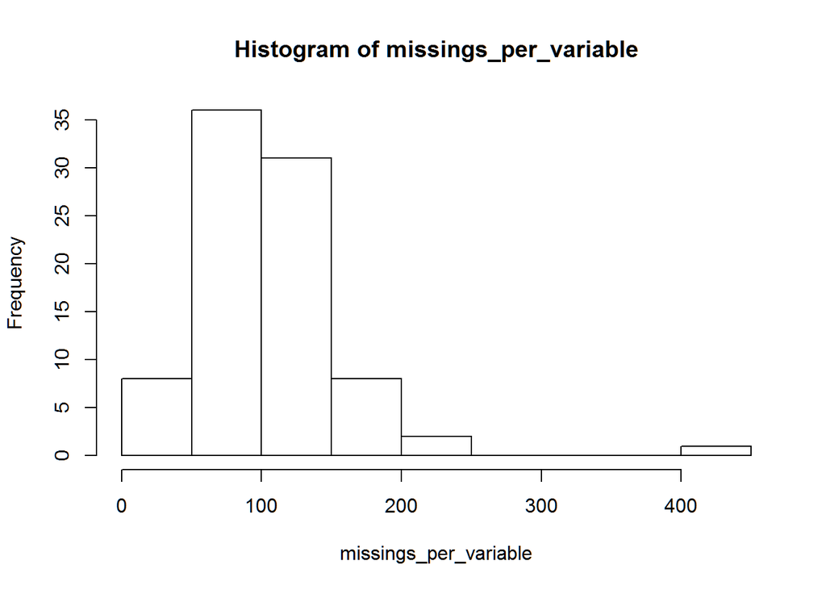

```r
missings = is.na(my_data)
missings_per_variable = colSums(missings)
hist(missings_per_variable)
```

Given that we have 18185 individuals, this look OK.

### Tables

We use facilities from the “psych” package to look at the data. The `describe` command makes a simple table with descriptive statistics. Here we specify that we do not want skew and kurosis statistics, because we already know that questionnaire items will not be normally distributed.

```r
library(psych)
describe(my_data,
         skew = F)
```

```
##                   vars     n    mean      sd min   max range    se
## PREG_ID_439          1 18185 9095.04 5250.57   2 18188 18186 38.94
## BARN_NR              2 18185    1.00    0.05   1     2     1  0.00
## KJONN                3 18185    1.49    0.50   1     2     1  0.00
## MORS_ALDER_KAT_K8    4 18185    4.80    0.92   1     8     7  0.01
## PARITET_5            5 18185    0.72    0.85   0     4     4  0.01
## FMND                 6 18185    5.94    3.39   1    12    11  0.03
## PSi.1*               7 18153    4.44    0.53   1     5     4  0.00
## PSi.2*               8 18108    2.12    0.78   1     5     4  0.01
## PSi.3*               9 18133    4.19    0.45   1     5     4  0.00
## PSi.4*              10 17965    2.03    0.83   1     5     4  0.01
## PSi.5*              11 18110    4.77    0.46   1     5     4  0.00
## PSi.6*              12 18127    4.65    0.49   1     5     4  0.00
## PSi.7*              13 18132    4.45    0.58   1     5     4  0.00
## PSi.8*              14 18113    4.22    0.59   1     5     4  0.00
## PSi.9*              15 17772    2.32    0.79   1     5     4  0.01
## SMFQi.1*            16 18018    1.48    0.53   1     3     2  0.00
## SMFQi.2*            17 18090    1.10    0.32   1     3     2  0.00
## SMFQi.3*            18 18072    1.24    0.46   1     3     2  0.00
## SMFQi.4*            19 18078    1.11    0.33   1     3     2  0.00
## SMFQi.5*            20 18072    1.10    0.31   1     3     2  0.00
## SMFQi.6*            21 18085    1.09    0.30   1     3     2  0.00
## SMFQi.7*            22 18074    1.05    0.23   1     3     2  0.00
## SMFQi.8*            23 18068    1.14    0.35   1     3     2  0.00
## SMFQi.9*            24 18069    1.11    0.33   1     3     2  0.00
## SMFQi.10*           25 18068    1.06    0.24   1     3     2  0.00
## SMFQi.11*           26 18058    1.06    0.24   1     3     2  0.00
## SMFQi.12*           27 18040    1.16    0.37   1     3     2  0.00
## SMFQi.13*           28 18043    1.21    0.43   1     3     2  0.00
## CCC2i.1*            29 18061    1.32    0.50   1     4     3  0.00
## CCC2i.2*            30 18027    1.45    0.58   1     4     3  0.00
## CCC2i.3*            31 18024    1.31    0.53   1     4     3  0.00
## CCC2i.4*            32 18039    1.15    0.38   1     4     3  0.00
## CCC2i.5*            33 18064    1.04    0.24   1     4     3  0.00
## CCC2i.6*            34 18052    1.08    0.30   1     4     3  0.00
## CCC2i.7*            35 18045    1.19    0.43   1     4     3  0.00
## CCC2i.8*            36 18031    1.36    0.53   1     4     3  0.00
## CCC2i.9*            37 18038    1.12    0.36   1     4     3  0.00
## CCC2i.10*           38 18038    3.24    0.84   1     4     3  0.01
## CCC2i.11*           39 18057    3.68    0.57   1     4     3  0.00
```

[output cut: 32 more lines]

```
## ADHDi.12*           72 18112    1.21    0.49   1     4     3  0.00
## ADHDi.13*           73 18108    1.19    0.45   1     4     3  0.00
## ADHDi.14*           74 18088    1.36    0.63   1     4     3  0.00
## ADHDi.15*           75 18108    1.43    0.67   1     4     3  0.00
## ADHDi.16*           76 18106    1.37    0.58   1     4     3  0.00
## ADHDi.17*           77 18109    1.39    0.58   1     4     3  0.00
## ADHDi.18*           78 18083    1.41    0.59   1     4     3  0.00
## ODi.1*              79 18108    1.36    0.59   1     4     3  0.00
## ODi.2*              80 18090    1.48    0.61   1     4     3  0.00
## ODi.3*              81 18089    1.41    0.59   1     4     3  0.00
## ODi.4*              82 18100    1.46    0.58   1     4     3  0.00
## ODi.5*              83 18086    1.52    0.62   1     4     3  0.00
## ODi.6*              84 18101    1.72    0.70   1     4     3  0.01
## ODi.7*              85 18107    1.44    0.59   1     4     3  0.00
## ODi.8*              86 18109    1.05    0.23   1     4     3  0.00
```

We can also easily generate stratified tables:

```r
my_data$KJONN = as_factor(my_data$KJONN)
ADHD_items = grep("ADHD",names(my_data))

describeBy(my_data[,ADHD_items],
           group = my_data$KJONN,
           skew = F)
```

```
##
##  Descriptive statistics by group
## group: Gutt
##           vars    n mean   sd min max range   se
## ADHDi.1*     1 9260 1.81 0.70   1   4     3 0.01
## ADHDi.2*     2 9259 1.53 0.67   1   4     3 0.01
## ADHDi.3*     3 9251 1.73 0.71   1   4     3 0.01
## ADHDi.4*     4 9266 1.28 0.59   1   4     3 0.01
## ADHDi.5*     5 9247 1.37 0.62   1   4     3 0.01
## ADHDi.6*     6 9261 1.77 0.76   1   4     3 0.01
## ADHDi.7*     7 9269 1.33 0.58   1   4     3 0.01
## ADHDi.8*     8 9262 2.11 0.75   1   4     3 0.01
## ADHDi.9*     9 9238 1.75 0.71   1   4     3 0.01
## ADHDi.10*   10 9250 1.81 0.90   1   4     3 0.01
## ADHDi.11*   11 9255 1.61 0.77   1   4     3 0.01
## ADHDi.12*   12 9264 1.28 0.55   1   4     3 0.01
## ADHDi.13*   13 9257 1.27 0.53   1   4     3 0.01
## ADHDi.14*   14 9242 1.43 0.69   1   4     3 0.01
## ADHDi.15*   15 9258 1.44 0.67   1   4     3 0.01
## ADHDi.16*   16 9259 1.39 0.59   1   4     3 0.01
## ADHDi.17*   17 9254 1.43 0.60   1   4     3 0.01
## ADHDi.18*   18 9250 1.43 0.60   1   4     3 0.01
## --------------------------------------------------------
## group: Pike
##           vars    n mean   sd min max range   se
## ADHDi.1*     1 8851 1.65 0.64   1   4     3 0.01
## ADHDi.2*     2 8845 1.35 0.58   1   4     3 0.01
## ADHDi.3*     3 8834 1.55 0.65   1   4     3 0.01
## ADHDi.4*     4 8852 1.15 0.44   1   4     3 0.00
## ADHDi.5*     5 8834 1.24 0.50   1   4     3 0.01
## ADHDi.6*     6 8856 1.52 0.65   1   4     3 0.01
## ADHDi.7*     7 8851 1.22 0.48   1   4     3 0.01
## ADHDi.8*     8 8848 1.94 0.70   1   4     3 0.01
## ADHDi.9*     9 8829 1.60 0.66   1   4     3 0.01
## ADHDi.10*   10 8848 1.56 0.78   1   4     3 0.01
## ADHDi.11*   11 8847 1.41 0.65   1   4     3 0.01
## ADHDi.12*   12 8848 1.14 0.40   1   4     3 0.00
## ADHDi.13*   13 8851 1.11 0.34   1   4     3 0.00
## ADHDi.14*   14 8846 1.29 0.57   1   4     3 0.01
## ADHDi.15*   15 8850 1.42 0.66   1   4     3 0.01
## ADHDi.16*   16 8847 1.35 0.56   1   4     3 0.01
## ADHDi.17*   17 8855 1.35 0.55   1   4     3 0.01
## ADHDi.18*   18 8833 1.39 0.58   1   4     3 0.01
```

And we can make simple cross-tabs:

```r
my_data$PARITET_5 = as_factor(my_data$PARITET_5)

xtabs(~KJONN + PARITET_5,
      my_data)
```

```
##       PARITET_5
## KJONN  0 (førstegangsfødende)    1  (2)    3 4 eller flere
##   Gutt                   4501 3250 1264  199            81
##   Pike                   4385 2948 1260  233            64
```

### Plots

One of the most populr R packges is `ggplot2`, because it allows to make even complex plots in a simple manner. (“gg” stands for grammar of graphics, which I do not feel competent to explain in detail. So we’ll just have a look at a few examples. See [here](http://r-statistics.co/Complete-Ggplot2-Tutorial-Part1-With-R-Code.html) for a detailed instroduction into ggplot2).

The simplest ggplot has the structure `ggplot(my_data, aes(my_mappings)) + geom_plottype()`. for example, we can make a simple histogram as follows:

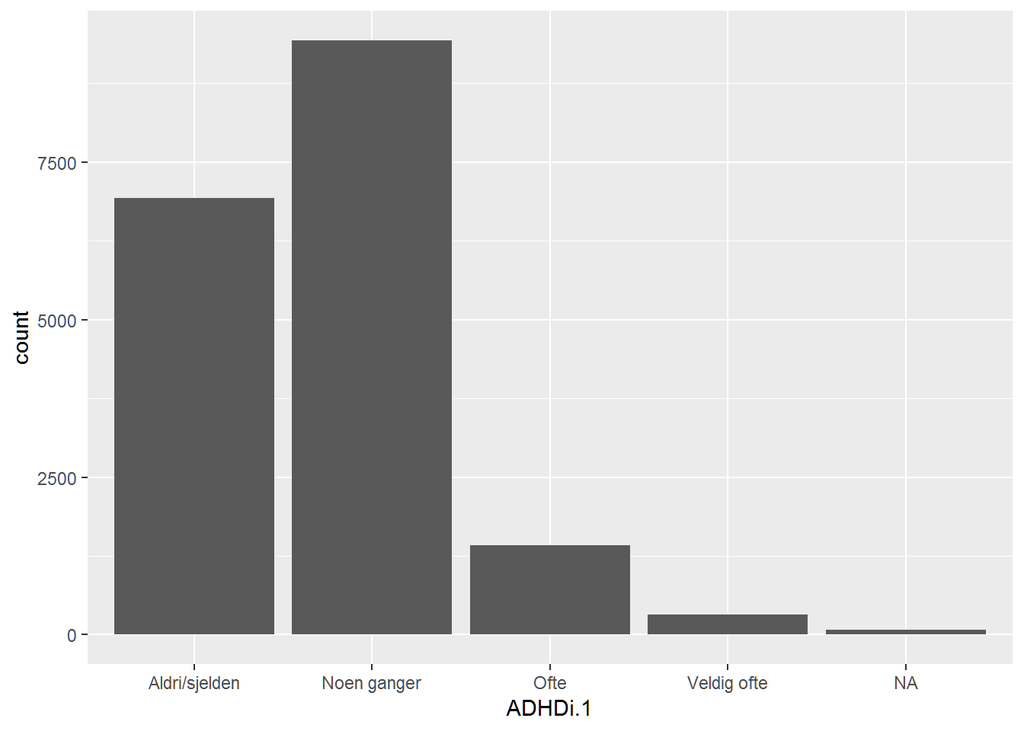

```r
library(ggplot2)
ggplot(my_data, aes(x = ADHDi.1)) +
  geom_histogram(stat = "count")
```

And we can extend this by stratifying after gender:

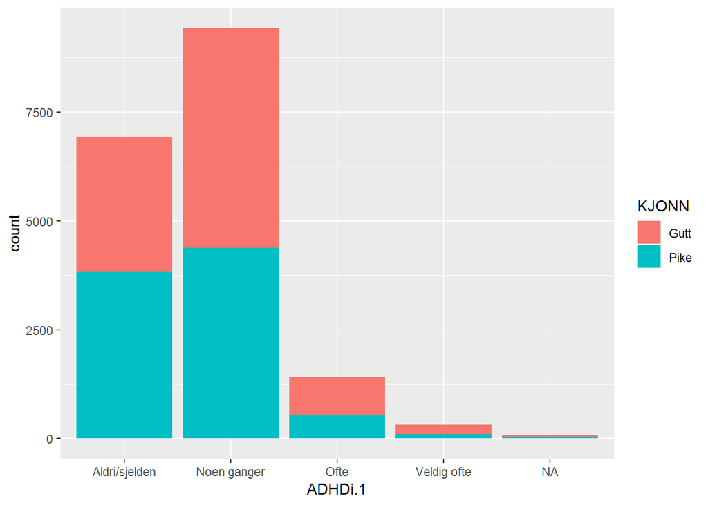

```r
ggplot(my_data, aes(x = ADHDi.1, fill = KJONN)) +
  geom_histogram(stat = "count")
```

If we don’t specify otherwise, we get stacked bars. But it is possible to have the bars siede-by-side.

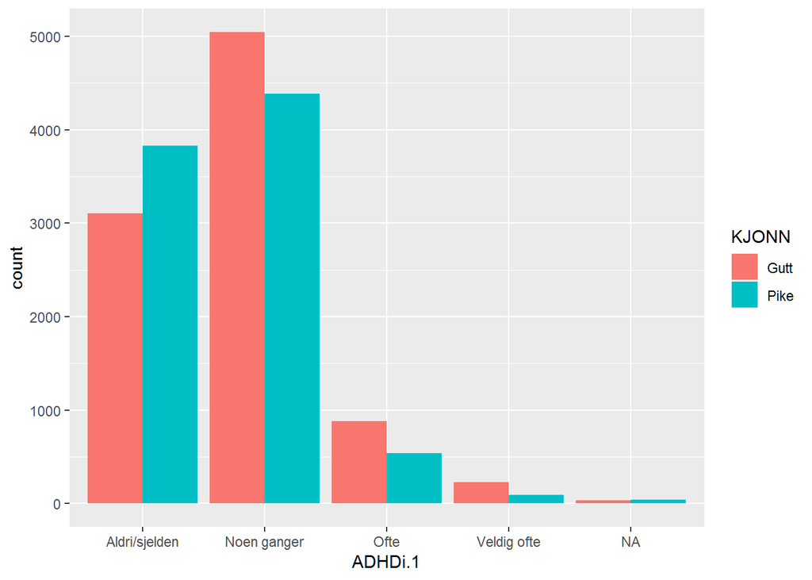

```r
ggplot(my_data, aes(x = ADHDi.1, fill = KJONN)) +
  geom_histogram(stat = "count", position = position_dodge())
```

Or we can make sub-plot by parity:

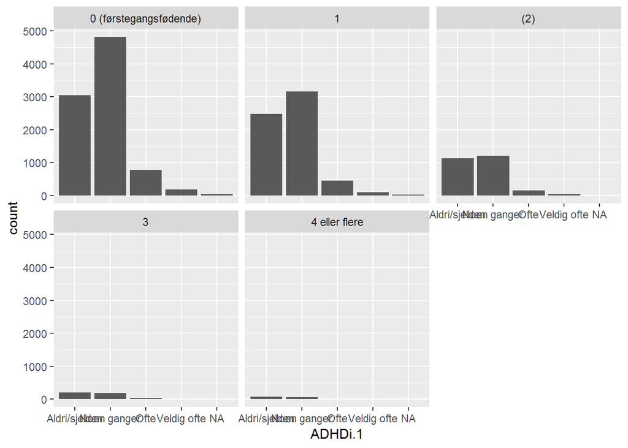

```r
ggplot(my_data, aes(x = ADHDi.1)) +
  geom_histogram(stat = "count") +
  facet_wrap(~PARITET_5)
```

The tick labels on the x axis are not gret here, but we can fix that:

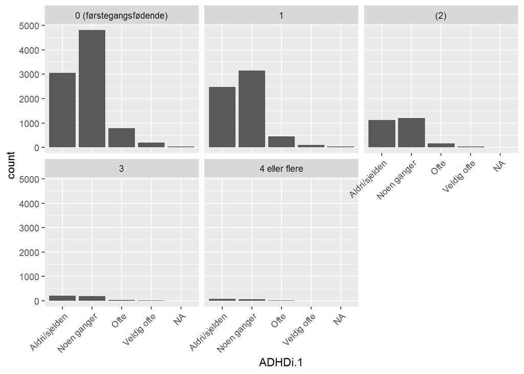

```r
ggplot(my_data, aes(x = ADHDi.1)) +
  geom_histogram(stat = "count") +
  facet_wrap(~PARITET_5) +
  theme(axis.text.x = element_text(angle = 45, hjust = 1))
```

At this moment it is maybe good to state clearly that one does not need to know all these commands by haert. One does need to know the basic types of plots and that one can adjust color, type of points, linetype etc. And given this basic konwledge one gets very far by just googeling `ggplot histogram` or `ggplot boxplot` …

We can also combine coloring by geneder and faceting by parity:

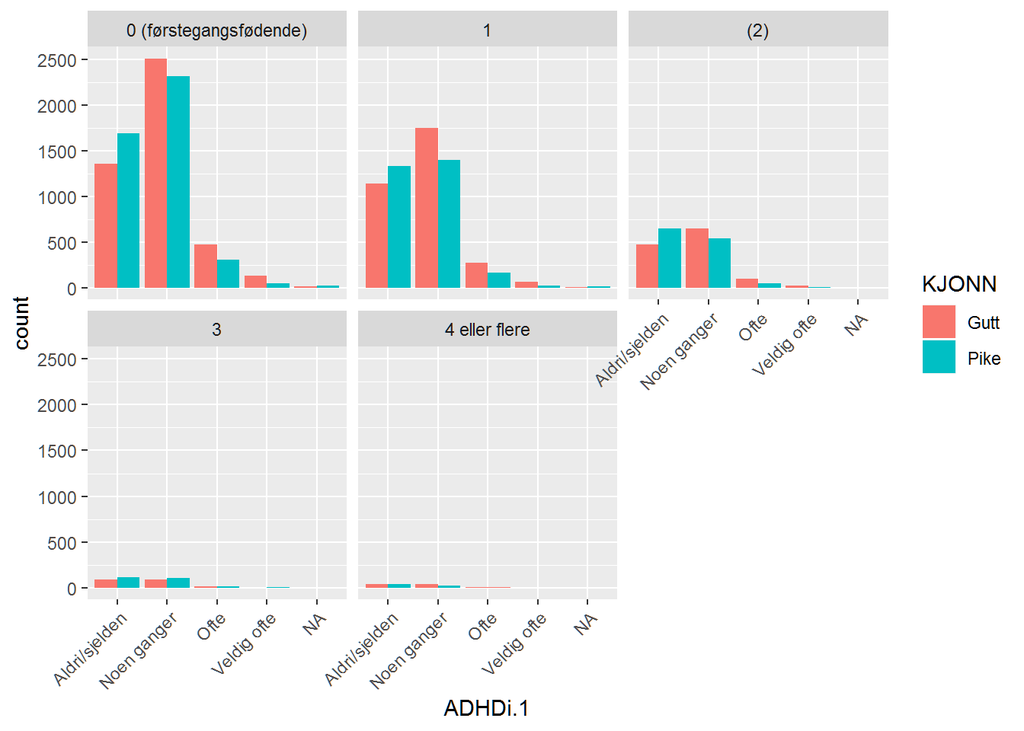

```r
ggplot(my_data, aes(x = ADHDi.1,fill = KJONN)) +
  geom_histogram(stat = "count",
                 position = position_dodge()) +
  facet_wrap(~PARITET_5) +
  theme(axis.text.x = element_text(angle = 45, hjust = 1))
```

However, the real advantage of ggplot is the possibility to make relatively complex plot with little effort. For example, we could be interested in ADHD symptoms strength by birth-months:

```r
library(tidyverse)
```

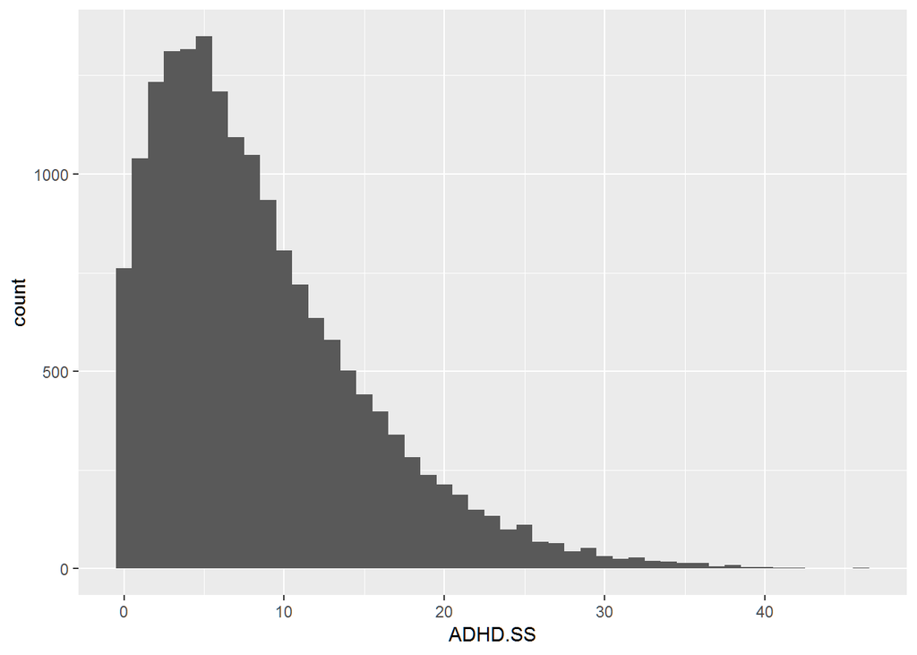

```r
ADHD_items = my_data[,grep("ADHDi",names(my_data))]
for (k in 1:ncol(ADHD_items))
  ADHD_items[,k] = as.numeric(ADHD_items[,k])


my_data$ADHD.SS = rowMeans(ADHD_items)*ncol(ADHD_items)-18

ggplot(my_data, aes(x = ADHD.SS)) + geom_histogram(binwidth = 1)
```

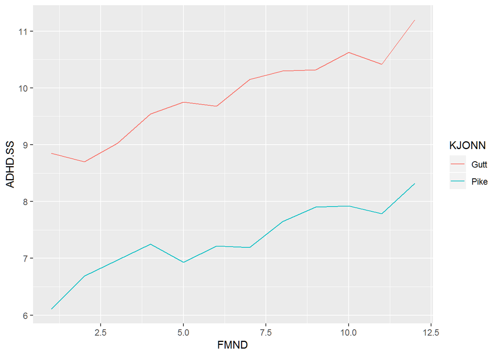

```r
ggplot(my_data, aes(x = FMND, y = ADHD.SS, color = KJONN)) +
  stat_summary(geom="line", fun.y="mean")
```

Finally, here is one of my favorite plots, which I use to get an overview over data: A *heatmap* plot of correlations between variables.

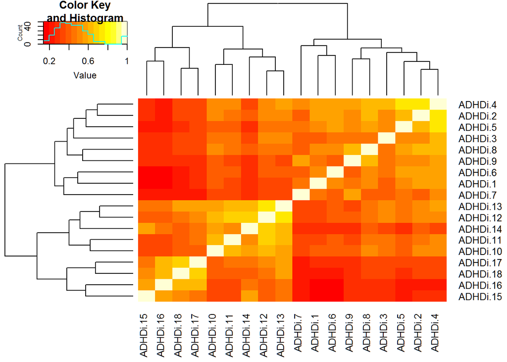

```r
library(gplots)
cormat = polychoric(ADHD_items)
rho = cormat$rho
heatmap.2(rho, trace = "none")
```